# Biostat 212a Homework 2

Due Feb 11, 2026 @ 11:59PM

Author

Max Vo ; 106784933

Published

February 11, 2026

**NOTE**: The Screenshots/ directory contains pdfs of the relevant exercises which might be higher quality than the inserted screenshot images.

## 1 ISL Exercise 4.8.1 (10pts)

Using a little bit of algebra, prove that (4.2) is equivalent to (4.3). In other words, the logistic function representation and logit represen- tation for the logistic regression model are equivalent.

**Logistic function (4.2):**
$$p(X) = \frac{e^{\beta_0 + \beta_1 X}}{1 + e^{\beta_0 + \beta_1 X}}$$

**Logit function (4.3):**
$$\frac{p(X)}{1 - p(X)} = e^{\beta_0 + \beta_1 X}$$
$$\log\left(\frac{p(X)}{1 - p(X)}\right) = \beta_0 + \beta_1 X$$

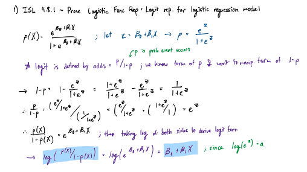

## 2 ISL Exercise 4.8.6 (10pts)

Suppose we collect data for a group of students in a statistics class with variables X1 = hours studied, X2 = undergrad GPA, and Y = receive an A. We fit a logistic regression and produce estimated coefficient, $\hat{\beta}_0 = −6, \hat{\beta}_1 = 0.05, \hat{\beta}_2 = 1$.

1. Estimate the probability that a student who studies for 40 h and has an undergrad GPA of 3.5 gets an A in the class.
2. How many hours would the student in part (a) need to study to have a 50 % chance of getting an A in the class?

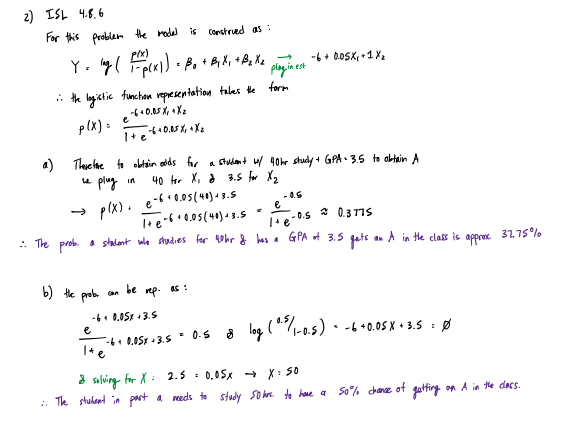

## 3 ISL Exercise 4.8.9 (10pts)

This problem has to do with odds. (a) On average, what fraction of people with an odds of 0.37 of defaulting on their credit card payment will in fact default? (b) Suppose that an individual has a 16 % chance of defaulting on her credit card payment. What are the odds that she will de- fault?

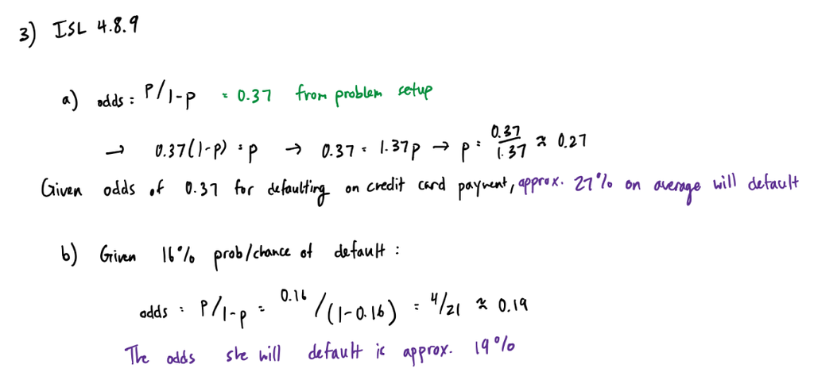

## 4 ISL Exercise 4.8.13 (a)-(i) (50pts) [applied question]

This question should be answered using the Weekly data set, which is part of the ISLR2 package. This data is similar in nature to the Smarket data from this chapter’s lab, except that it contains 1,089 weekly returns for 21 years, from the beginning of 1990 to the end of 2010.

```r
library(ISLR2)
library(tidyverse)
library(ggplot2)
```

```r
# load the data and take a look at the first few rows
ISLR2::Weekly %>% head()
```

```
  Year   Lag1   Lag2   Lag3   Lag4   Lag5    Volume  Today Direction
1 1990  0.816  1.572 -3.936 -0.229 -3.484 0.1549760 -0.270      Down
2 1990 -0.270  0.816  1.572 -3.936 -0.229 0.1485740 -2.576      Down
3 1990 -2.576 -0.270  0.816  1.572 -3.936 0.1598375  3.514        Up
4 1990  3.514 -2.576 -0.270  0.816  1.572 0.1616300  0.712        Up
5 1990  0.712  3.514 -2.576 -0.270  0.816 0.1537280  1.178        Up
6 1990  1.178  0.712  3.514 -2.576 -0.270 0.1544440 -1.372      Down
```

### 4.1 (a)

Produce some numerical and graphical summaries of the Weekly data. Do there appear to be any patterns?

```r
# numerical summaries
Weekly %>%  summary()
```

```
      Year           Lag1               Lag2               Lag3
 Min.   :1990   Min.   :-18.1950   Min.   :-18.1950   Min.   :-18.1950
 1st Qu.:1995   1st Qu.: -1.1540   1st Qu.: -1.1540   1st Qu.: -1.1580
 Median :2000   Median :  0.2410   Median :  0.2410   Median :  0.2410
 Mean   :2000   Mean   :  0.1506   Mean   :  0.1511   Mean   :  0.1472
 3rd Qu.:2005   3rd Qu.:  1.4050   3rd Qu.:  1.4090   3rd Qu.:  1.4090
 Max.   :2010   Max.   : 12.0260   Max.   : 12.0260   Max.   : 12.0260
      Lag4               Lag5              Volume            Today
 Min.   :-18.1950   Min.   :-18.1950   Min.   :0.08747   Min.   :-18.1950
 1st Qu.: -1.1580   1st Qu.: -1.1660   1st Qu.:0.33202   1st Qu.: -1.1540
 Median :  0.2380   Median :  0.2340   Median :1.00268   Median :  0.2410
 Mean   :  0.1458   Mean   :  0.1399   Mean   :1.57462   Mean   :  0.1499
 3rd Qu.:  1.4090   3rd Qu.:  1.4050   3rd Qu.:2.05373   3rd Qu.:  1.4050
 Max.   : 12.0260   Max.   : 12.0260   Max.   :9.32821   Max.   : 12.0260
 Direction
 Down:484
 Up  :605
```

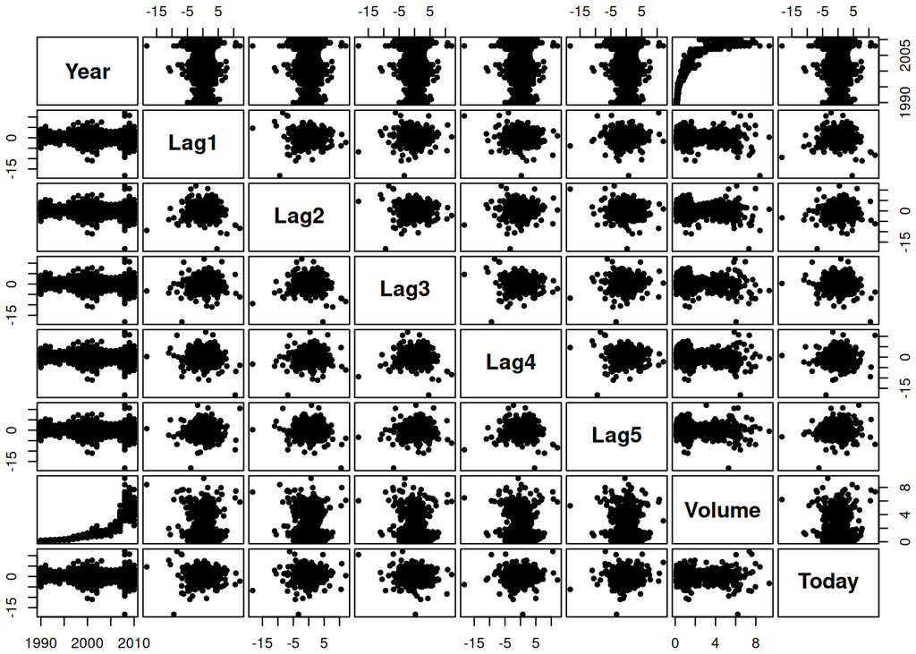

```r
# graphical summaries; leave out the Direction variable since it is binary

# pairwise scatterplots of the predictors
pairs(Weekly[, -9], pch = 20, cex.labels = 1.5, font.labels = 2,
      gap = 0.3, oma = c(2, 2, 2, 2),
      labels = colnames(Weekly[, -9]))
```

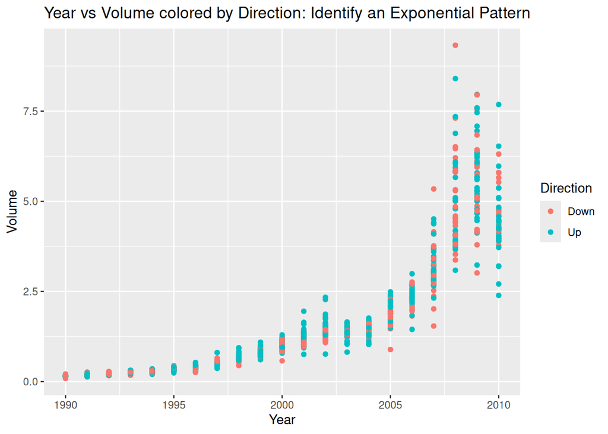

```r
# Manual Scatterplot of Lag1 vs Lag2 colored by Direction
Weekly %>%  ggplot(aes(x = Year, y = Volume, color = Direction)) +
  geom_point() +
  labs(title = "Year vs Volume colored by Direction: Identify an Exponential Pattern")
```

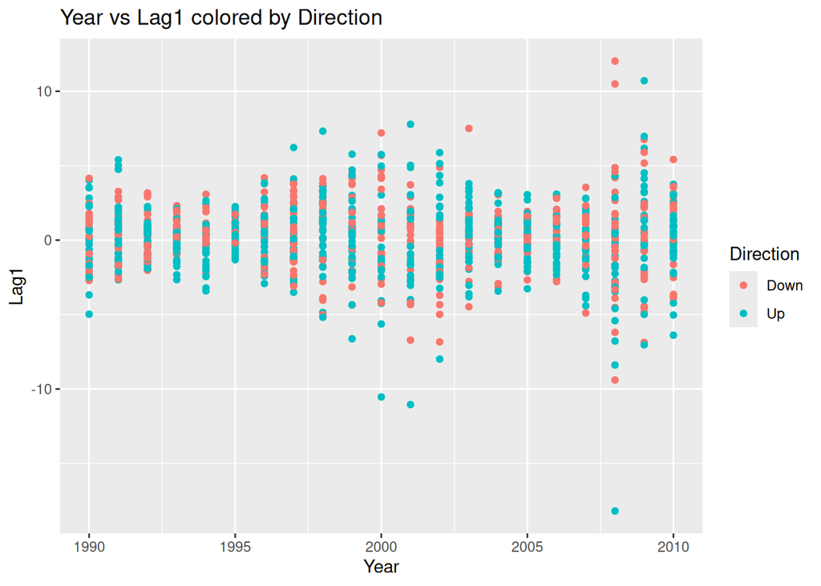

```r
# additional manual plots to look at patterns
Weekly %>%  ggplot(aes(x = Year, y = Lag1, color = Direction)) +
  geom_point() +
  labs(title = "Year vs Lag1 colored by Direction")
```

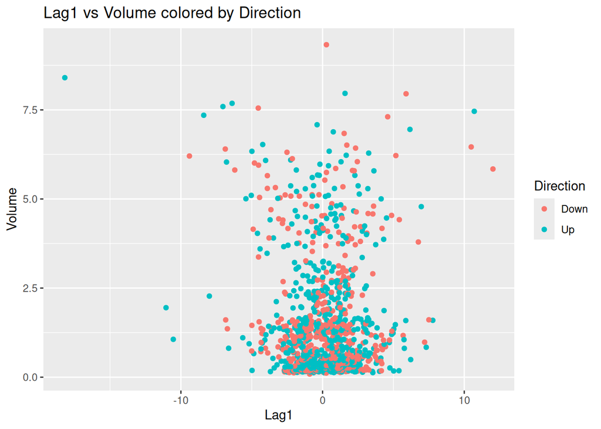

```r
Weekly %>%  ggplot(aes(x = Lag1, y = Volume, color = Direction)) +
  geom_point() +
  labs(title = "Lag1 vs Volume colored by Direction")
```

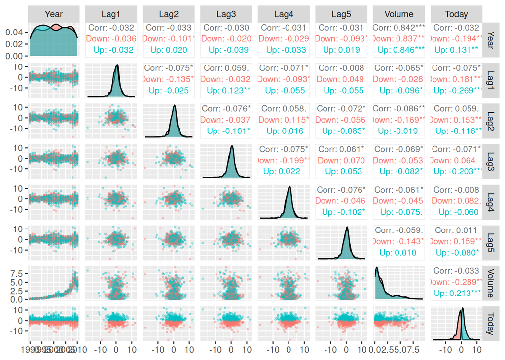

```r
library(GGally)
ggpairs(Weekly, columns = 1:8, aes(color = Direction, alpha = 0.5),
        lower = list(continuous = wrap("points", alpha = 0.3, size = 0.5)),
        upper = list(continuous = wrap("cor", size = 3))) # pairwise scatterplots with color by Direction
```

Additionally, there seems to be little correlation be little correlation between Lag# variables with other Lag# variables and with Year. (spread of points across a roughly horizontal line) For Lag# against Volume, there seems to be little variation in Volume across possible vaalues of Lag#. (the spread of points around a roughly vertical line)

### 4.2 (b)

Use the full data set to perform a logistic regression with Direction as the response and the five lag variables plus Volume as predictors. Use the summary function to print the results. Do any of the predictors appear to be statistically significant? If so, which ones?

```r
# fitting logistic regression model with Direction as response and Lag1, Lag2, Lag3, Lag4, Lag5, Volume as predictors
logistic_model <- glm(Direction ~ Lag1 + Lag2 + Lag3 + Lag4 + Lag5 + Volume, data = Weekly, family = binomial)
summary(logistic_model)
```

```
Call:
glm(formula = Direction ~ Lag1 + Lag2 + Lag3 + Lag4 + Lag5 +
    Volume, family = binomial, data = Weekly)

Coefficients:
            Estimate Std. Error z value Pr(>|z|)
(Intercept)  0.26686    0.08593   3.106   0.0019 **
Lag1        -0.04127    0.02641  -1.563   0.1181
Lag2         0.05844    0.02686   2.175   0.0296 *
Lag3        -0.01606    0.02666  -0.602   0.5469
Lag4        -0.02779    0.02646  -1.050   0.2937
Lag5        -0.01447    0.02638  -0.549   0.5833
Volume      -0.02274    0.03690  -0.616   0.5377
---
Signif. codes:  0 '***' 0.001 '**' 0.01 '*' 0.05 '.' 0.1 ' ' 1

(Dispersion parameter for binomial family taken to be 1)

    Null deviance: 1496.2  on 1088  degrees of freedom
Residual deviance: 1486.4  on 1082  degrees of freedom
AIC: 1500.4

Number of Fisher Scoring iterations: 4
```

The predictor that appears to be statistically significant in the logistic regression model with `Direction` as the response and the five lag variables plus `Volume` as predictors is `Lag2` at the 0.05 significance level (p-value = 0.0296).

NOTE: if we also include `Today` as a predictor, then `Today` is also statistically significant at the 0.05 significance level.

### 4.3 (c)

Compute the confusion matrix and overall fraction of correct predictions. Explain what the confusion matrix is telling you about the types of mistakes made by logistic regression.

https://www.digitalocean.com/community/tutorials/confusion-matrix-in-r

```r
library(caret)

# predict the probabilities of the positive class (Up) using the logistic regression model
probs <- predict(logistic_model, type = "response")

# convert probabilities to factor class labels using 0.5 threshold
# 0.5 is a loigical decision boundary: if P > 0.5, classify as "Up", else "Down"
predicted_direction <- factor(ifelse(probs > 0.5, "Up", "Down"),
                              levels = levels(Weekly$Direction))

# the data must be treated this way, since the confusionMatrix function expects factor variables with the same levels for both data and reference
confusion_matrix <- confusionMatrix(data = predicted_direction,
                                    reference = Weekly$Direction,
                                    positive = "Up")
confusion_matrix
```

```
Confusion Matrix and Statistics

          Reference
Prediction Down  Up
      Down   54  48
      Up    430 557

               Accuracy : 0.5611
                 95% CI : (0.531, 0.5908)
    No Information Rate : 0.5556
    P-Value [Acc > NIR] : 0.369

                  Kappa : 0.035

 Mcnemar's Test P-Value : <2e-16

            Sensitivity : 0.9207
            Specificity : 0.1116
         Pos Pred Value : 0.5643
         Neg Pred Value : 0.5294
             Prevalence : 0.5556
         Detection Rate : 0.5115
   Detection Prevalence : 0.9063
      Balanced Accuracy : 0.5161

       'Positive' Class : Up
```

```r
# Extracting specifically the accuracy of the model (overall fraction of correct predictions)
model_accuracy <- confusion_matrix$overall['Accuracy']
model_accuracy
```

```
 Accuracy
0.5610652
```

Note that execution of the confusion_matrix object prints out both the confusion matrix table and relevant statistics such as accuracy, sensitivity, and specificity. We can also calculate other statuistics:

If we consider the “Up” class as the positive class, then we can calculate the following statistics Manually:

- TPR (Sensitivity) = TP / (TP + FN) = 557 / (557 + 48) = 0.921
- TNR (Specificity) = TN / (TN + FP) = 54 / (54 + 430) = 0.112
- FPR = FP / (FP + TN) = 430 / (430 + 54) = 0.888
- FNR = FN / (TP + FN) = 48 / (557 + 48) = 0.079
- Positive Predictive Value (PPV) = TP / (TP + FP) = 557 / (557 + 430) = 0.564
- Negative Predictive Value (NPV) = TN / (TN + FN) = 54 / (54 + 48) = 0.529

These values tell us that the logistic regression model is very good at correctly identifying “Up” weeks (high sensitivity), but it is not good at correctly identifying “Down” weeks (low specificity). The model has a high false positive rate, meaning that it often incorrectly predicts “Up” when the actual outcome is “Down”. Inversly, low false negative rate indicates that the model is good at correctly identifying “Up” weeks, but the high false positive rate indicates that it struggles to correctly identify “Down” weeks.

The positive predictive value (accuracy/precision) indicates that when the model predicts “Up”, it is correct about 56.4% of the time, while the negative predictive value indicates that when the model predicts “Down”, it is correct about 52.9% of the time.

This reflects the fact that the model has a bias towards predicting “Up” weeks, which may be due to the imbalance in the dataset (more “Up” weeks than “Down” weeks) or due to the nature of the predictors used in the logistic model.

### 4.4 (d)

Now fit the logistic regression model using a training data period from 1990 to 2008, with Lag2 as the only predictor. Compute the confusion matrix and the overall fraction of correct predictions for the held out data (that is, the data from 2009 and 2010).

- Lag2 as the only predictor
- training data period from 1990 to 2008
- held out data from 2009 and 2010

```r
# filter dplyr does not require sorting but, it makes it easier to visualize
Weekly_sorted <- Weekly %>% arrange(Year)

# split data by specified criteria for training and testing
train_data <- Weekly_sorted %>% filter(Year >= 1990 & Year <= 2008)
test_data <- Weekly_sorted %>% filter(Year >= 2009 & Year <= 2010)
```

```r
# fit logistic model w/ Lag2 as the only predictor on the training data
logistic_model_lag2 <- glm(Direction ~ Lag2, data = train_data, family = binomial)
summary(logistic_model_lag2)
```

```
Call:
glm(formula = Direction ~ Lag2, family = binomial, data = train_data)

Coefficients:
            Estimate Std. Error z value Pr(>|z|)
(Intercept)  0.20326    0.06428   3.162  0.00157 **
Lag2         0.05810    0.02870   2.024  0.04298 *
---
Signif. codes:  0 '***' 0.001 '**' 0.01 '*' 0.05 '.' 0.1 ' ' 1

(Dispersion parameter for binomial family taken to be 1)

    Null deviance: 1354.7  on 984  degrees of freedom
Residual deviance: 1350.5  on 983  degrees of freedom
AIC: 1354.5

Number of Fisher Scoring iterations: 4
```

```r
# predict probabilities on the test data using the fitted model

# use type = "response" since we want to set the probability-related threshold for classification (0.5) and not the log-odds threshold (0)
probs_test <- predict(logistic_model_lag2, newdata = test_data, type = "response")
predicted_direction_test <- factor(ifelse(probs_test > 0.5, "Up", "Down"),
                                   levels = levels(test_data$Direction))
confusion_matrix_test <- confusionMatrix(data = predicted_direction_test,
                                         reference = test_data$Direction,
                                         positive = "Up")
confusion_matrix_test
```

```
Confusion Matrix and Statistics

          Reference
Prediction Down Up
      Down    9  5
      Up     34 56

               Accuracy : 0.625
                 95% CI : (0.5247, 0.718)
    No Information Rate : 0.5865
    P-Value [Acc > NIR] : 0.2439

                  Kappa : 0.1414

 Mcnemar's Test P-Value : 7.34e-06

            Sensitivity : 0.9180
            Specificity : 0.2093
         Pos Pred Value : 0.6222
         Neg Pred Value : 0.6429
             Prevalence : 0.5865
         Detection Rate : 0.5385
   Detection Prevalence : 0.8654
      Balanced Accuracy : 0.5637

       'Positive' Class : Up
```

The overall fraction of correct predictions for the held out data which can be represented as [TP+TN] / [TP + TN + FP + FN] or model accuracy is 0.625, which is the accuracy of the model using the training data (1990-2008) to predict the test data (2009-2010) using Lag2 as the only predictor.

### 4.5 (e) Repeat (d) using LDA.

```r
# load in the MASS package for LDA
library(MASS)
```

```r
# fit LDA model w/ Lag2 as the only predictor on the training data
lda_lag2 <- lda(Direction ~ Lag2, data = train_data)
lda_lag2
```

```
Call:
lda(Direction ~ Lag2, data = train_data)

Prior probabilities of groups:
     Down        Up
0.4477157 0.5522843

Group means:
            Lag2
Down -0.03568254
Up    0.26036581

Coefficients of linear discriminants:
           LD1
Lag2 0.4414162
```

```r
# predict on the test data using the fitted LDA model

# whearas predict.glm returns a numeric vector of probabilities, predict.lda returns a factor variable with predicted class labels and posterior probabilities for each class
lda_predictions <- predict(lda_lag2, newdata = test_data)
predicted_direction_lda <- lda_predictions$class
confusion_matrix_lda <- confusionMatrix(data = predicted_direction_lda,
                                       reference = test_data$Direction,
                                       positive = "Up")
confusion_matrix_lda
```

```
Confusion Matrix and Statistics

          Reference
Prediction Down Up
      Down    9  5
      Up     34 56

               Accuracy : 0.625
                 95% CI : (0.5247, 0.718)
    No Information Rate : 0.5865
    P-Value [Acc > NIR] : 0.2439

                  Kappa : 0.1414

 Mcnemar's Test P-Value : 7.34e-06

            Sensitivity : 0.9180
            Specificity : 0.2093
         Pos Pred Value : 0.6222
         Neg Pred Value : 0.6429
             Prevalence : 0.5865
         Detection Rate : 0.5385
   Detection Prevalence : 0.8654
      Balanced Accuracy : 0.5637

       'Positive' Class : Up
```

The overall fraction of correct predictions for the held out data using LDA with Lag2 as the only predictor is 0.625, which is the same as the accuracy obtained from logistic regression in part (d). Moreover, the TP, TN, FP, and FN values are also the same for both models, indicating that both logistic regression and LDA made the same predictions on the test data when using Lag2 as the only predictor.

### 4.6 (f) Repeat (d) using QDA.

QDA is also available in the MASS package, and has a similar workflow to LDA.

```r
# fit QDA model w/ Lag2 as the only predictor on the training data
qda_lag2 <- qda(Direction ~ Lag2, data = train_data)
qda_lag2
```

```
Call:
qda(Direction ~ Lag2, data = train_data)

Prior probabilities of groups:
     Down        Up
0.4477157 0.5522843

Group means:
            Lag2
Down -0.03568254
Up    0.26036581
```

```r
# predict on the test data using the fitted QDA model
qda_predictions <- predict(qda_lag2, newdata = test_data)
predicted_direction_qda <- qda_predictions$class
confusion_matrix_qda <- confusionMatrix(data = predicted_direction_qda,
                                       reference = test_data$Direction,
                                       positive = "Up")
confusion_matrix_qda
```

```
Confusion Matrix and Statistics

          Reference
Prediction Down Up
      Down    0  0
      Up     43 61

               Accuracy : 0.5865
                 95% CI : (0.4858, 0.6823)
    No Information Rate : 0.5865
    P-Value [Acc > NIR] : 0.5419

                  Kappa : 0

 Mcnemar's Test P-Value : 1.504e-10

            Sensitivity : 1.0000
            Specificity : 0.0000
         Pos Pred Value : 0.5865
         Neg Pred Value :    NaN
             Prevalence : 0.5865
         Detection Rate : 0.5865
   Detection Prevalence : 1.0000
      Balanced Accuracy : 0.5000

       'Positive' Class : Up
```

The overall fraction of correct predictions for the held out data using QDA with Lag2 as the only predictor is approximately 0.587, which is lower than the accuracy obtained from logistic regression and LDA in part (d) and (e). In actuality, the QDA model performs much worse as it predicts “Up” for all test observations, which means although it correctly identifies all “Up” weeks (TP = 61), it fails to identify any “Down” weeks (TN = 0), resulting in a high number of false positives (FP = 43) and no true negatives (TN = 0). This leads to a lower overall accuracy compared to the logistic regression and LDA models.

### 4.7 (g) Repeat (d) using KNN with K = 1.

Utilize `class` package for simple KNN. (could also use `caret`)

```r
library(class)

# knn expects the training and test data to be in matrix or data frame format, and the class labels to be a factor variable.
knn_predictions <- knn(train = data.frame(train_data$Lag2),
                       test = data.frame(test_data$Lag2),
                       cl = train_data$Direction, k = 1)
confusion_matrix_knn <- confusionMatrix(data = knn_predictions,
                                       reference = test_data$Direction,
                                       positive = "Up")
confusion_matrix_knn
```

```
Confusion Matrix and Statistics

          Reference
Prediction Down Up
      Down   21 30
      Up     22 31

               Accuracy : 0.5
                 95% CI : (0.4003, 0.5997)
    No Information Rate : 0.5865
    P-Value [Acc > NIR] : 0.9700

                  Kappa : -0.0033

 Mcnemar's Test P-Value : 0.3317

            Sensitivity : 0.5082
            Specificity : 0.4884
         Pos Pred Value : 0.5849
         Neg Pred Value : 0.4118
             Prevalence : 0.5865
         Detection Rate : 0.2981
   Detection Prevalence : 0.5096
      Balanced Accuracy : 0.4983

       'Positive' Class : Up
```

### 4.8 (h) Repeat (d) using naive Bayes.

```r
# load in the e1071 package for naive Bayes
library(e1071)
```

```r
# fit naive Bayes model w/ Lag2 as the only predictor on the training data
naive_bayes_lag2 <- naiveBayes(Direction ~ Lag2, data = train_data)
naive_bayes_lag2
```

```
Naive Bayes Classifier for Discrete Predictors

Call:
naiveBayes.default(x = X, y = Y, laplace = laplace)

A-priori probabilities:
Y
     Down        Up
0.4477157 0.5522843

Conditional probabilities:
      Lag2
Y             [,1]     [,2]
  Down -0.03568254 2.199504
  Up    0.26036581 2.317485
```

```r
# predict on the test data using the fitted naive Bayes model
# predict.naiveBayes returns also returns a factor variable with predicted class labels and posterior probabilities for each class
naive_bayes_predictions <- predict(naive_bayes_lag2, newdata = test_data)
confusion_matrix_nb <- confusionMatrix(data = naive_bayes_predictions,
                                      reference = test_data$Direction,
                                      positive = "Up")
confusion_matrix_nb
```

```
Confusion Matrix and Statistics

          Reference
Prediction Down Up
      Down    0  0
      Up     43 61

               Accuracy : 0.5865
                 95% CI : (0.4858, 0.6823)
    No Information Rate : 0.5865
    P-Value [Acc > NIR] : 0.5419

                  Kappa : 0

 Mcnemar's Test P-Value : 1.504e-10

            Sensitivity : 1.0000
            Specificity : 0.0000
         Pos Pred Value : 0.5865
         Neg Pred Value :    NaN
             Prevalence : 0.5865
         Detection Rate : 0.5865
   Detection Prevalence : 1.0000
      Balanced Accuracy : 0.5000

       'Positive' Class : Up
```

Naive Bayes with Lag2 as the only predictor performs identically to QDA, with an accuracy of approximately 0.587. Both models predict “Up” for all test observations, resulting in TP = 61, TN = 0, FP = 43, and FN = 0. This indicates that the Naive Bayes model, like QDA, is unable to correctly identify any “Down” weeks in the test data.

Conducting research to understand why this happens, it turns out QDA with a single continuous predictor fits a seperate means and variance for each class which is equivalent to QDA does with a single continuous predictor.

## 5 Bonus question: ISL Exercise 4.8.13 Part (j) (30pts)

10. Experiment with different combinations of predictors, including possible transformations and interactions, for each of the methods. Report the variables, method, and associated confusion matrix that appears to provide the best results on the held out data. Note that you should also experiment with values for K in the KNN classifier.

We cannot use the leaps package for subset selection since our problem is classification and not regression, but we can use the `caret` package to perform feature selection using recursive feature elimination (RFE) or other methods.

```r
# Direction is essentially just the sign of the Today variable, so we should eclude the Today variable from our predictors
train_notoday <- train_data %>% dplyr::select(-Today)
test_notoday <- test_data %>% dplyr::select(-Today)
```

```r
# first trying on logistic regression since it performed well

# Lag2 + interaction
glm_1 <- glm(Direction ~ Lag2 * Lag1, data = train_notoday, family = binomial)

# Lag2 + Lag2^2 (quadratic transformation)
glm_2 <- glm(Direction ~ poly(Lag2, 2), data = train_notoday, family = binomial)

# Multiple lags
glm_3 <- glm(Direction ~ Lag1 + Lag2 + Lag3, data = train_notoday, family = binomial)

# Lag2 with Volume interaction
glm_4 <- glm(Direction ~ Lag2 * Volume, data = train_notoday, family = binomial)

# Log transform of Volume
glm_5 <- glm(Direction ~ Lag2 + log(Volume), data = train_notoday, family = binomial)
```

```r
# function to evaluate glm model performance on test data
eval_glm <- function(model, test_data){
  probs <- predict(model, newdata = test_data, type = "response")
  preds <- factor(ifelse(probs > 0.5, "Up", "Down"),
                  levels = levels(test_data$Direction))
  confusionMatrix(data = preds, reference = test_data$Direction,
                  positive = "Up")
}

cat("GLM 1: Lag2 * Lag1 interaction\n")
```

```
GLM 1: Lag2 * Lag1 interaction
```

```r
print(eval_glm(glm_1, test_notoday)$overall['Accuracy'])
```

```
 Accuracy
0.5769231
```

```r
cat("\nGLM 2: poly(Lag2, 2) quadratic transformation\n")
```

```
GLM 2: poly(Lag2, 2) quadratic transformation
```

```r
print(eval_glm(glm_2, test_notoday)$overall['Accuracy'])
```

```
Accuracy
   0.625
```

```r
cat("\nGLM 3: Lag1 + Lag2 + Lag3\n")
```

```
GLM 3: Lag1 + Lag2 + Lag3
```

```r
print(eval_glm(glm_3, test_notoday)$overall['Accuracy'])
```

```
 Accuracy
0.5769231
```

```r
cat("\nGLM 4: Lag2 * Volume interaction\n")
```

```
GLM 4: Lag2 * Volume interaction
```

```r
print(eval_glm(glm_4, test_notoday)$overall['Accuracy'])
```

```
 Accuracy
0.5384615
```

```r
cat("\nGLM 5: Lag2 + log(Volume)\n")
```

```
GLM 5: Lag2 + log(Volume)
```

```r
print(eval_glm(glm_5, test_notoday)$overall['Accuracy'])
```

```
 Accuracy
0.5769231
```

From this testing, we see that the model with the highest accuracy on the test data is GLM 2, which includes a quadratic transformation of Lag2. This model achieves an accuracy of approximately 0.625, which is the same as the original logistic regression model with only Lag2 as a predictor. However, the other models with interactions and multiple predictors did not improve the accuracy on the test data, indicating that they may be overfitting to the training data or that the additional predictors do not provide useful information for predicting the Direction variable. I did find the interasting quirk that taking the log of Volume as a predictor improves the model. (accuracy of GLM 5 is greater than GLM 4, but the model still performs worse than the original model with only Lag2 as a predictor)

```r
nrow(test_notoday)
```

```
[1] 104
```

```r
# further exploration with KNN, using Lag2 only
# Try different K values for KNN
for (k in c(1, 3, 5, 10, 20, 50, 100)) {
  knn_pred <- knn(train = data.frame(train_notoday$Lag2),
                  test = data.frame(test_notoday$Lag2),
                  cl = train_notoday$Direction, k = k)
  acc <- mean(knn_pred == test_notoday$Direction)
  cat("K =", k, "Accuracy =", round(acc, 4), "\n")
}
```

```
K = 1 Accuracy = 0.5096
K = 3 Accuracy = 0.5385
K = 5 Accuracy = 0.5288
K = 10 Accuracy = 0.6058
K = 20 Accuracy = 0.5865
K = 50 Accuracy = 0.5385
K = 100 Accuracy = 0.5577
```

```r
# KNN with Lag2 and log(Volume) as predictors
train_knn <- train_notoday %>% dplyr::select(Lag2, Volume) %>% mutate(Volume = log(Volume))
test_knn <- test_notoday %>% dplyr::select(Lag2, Volume) %>% mutate(Volume = log(Volume))
for (k in c(1, 3, 5, 10, 20, 50, 100)) {
  knn_pred <- knn(train = train_knn,
                  test = test_knn,
                  cl = train_notoday$Direction, k = k)
  acc <- mean(knn_pred == test_notoday$Direction)
  cat("K =", k, "Accuracy =", round(acc, 4), "\n")
}
```

```
K = 1 Accuracy = 0.5481
K = 3 Accuracy = 0.5288
K = 5 Accuracy = 0.5385
K = 10 Accuracy = 0.5
K = 20 Accuracy = 0.5481
K = 50 Accuracy = 0.5962
K = 100 Accuracy = 0.6154
```

For this example, there is a slight U-shape for accuracy as K increases, with the highest accuracy occuring at very large K (plateau at accuracy of 0.6154). This tells us that there is little local structure in Lag2+log(Volume) that is useful for predicting Direction.

```r
# additional exploration of the notable Lag2 + log(Volume) in other methods
lda_lag2_logvol <- lda(Direction ~ Lag2 + log(Volume), data = train_notoday)
lda_pred <- predict(lda_lag2_logvol, newdata = test_notoday)
confusion_matrix_lda_logvol <- confusionMatrix(data = lda_pred$class,
                                               reference = test_notoday$Direction,
                                               positive = "Up")
confusion_matrix_lda_logvol
```

```
Confusion Matrix and Statistics

          Reference
Prediction Down Up
      Down   14 15
      Up     29 46

               Accuracy : 0.5769
                 95% CI : (0.4761, 0.6732)
    No Information Rate : 0.5865
    P-Value [Acc > NIR] : 0.61933

                  Kappa : 0.0837

 Mcnemar's Test P-Value : 0.05002

            Sensitivity : 0.7541
            Specificity : 0.3256
         Pos Pred Value : 0.6133
         Neg Pred Value : 0.4828
             Prevalence : 0.5865
         Detection Rate : 0.4423
   Detection Prevalence : 0.7212
      Balanced Accuracy : 0.5398

       'Positive' Class : Up
```

```r
qda_lag2_logvol <- qda(Direction ~ Lag2 + log(Volume), data = train_notoday)
qda_pred <- predict(qda_lag2_logvol, newdata = test_notoday)
confusion_matrix_qda_logvol <- confusionMatrix(data = qda_pred$class,
                                               reference = test_notoday$Direction,
                                               positive = "Up")
confusion_matrix_qda_logvol
```

```
Confusion Matrix and Statistics

          Reference
Prediction Down Up
      Down   21 24
      Up     22 37

               Accuracy : 0.5577
                 95% CI : (0.457, 0.655)
    No Information Rate : 0.5865
    P-Value [Acc > NIR] : 0.7579

                  Kappa : 0.0943

 Mcnemar's Test P-Value : 0.8828

            Sensitivity : 0.6066
            Specificity : 0.4884
         Pos Pred Value : 0.6271
         Neg Pred Value : 0.4667
             Prevalence : 0.5865
         Detection Rate : 0.3558
   Detection Prevalence : 0.5673
      Balanced Accuracy : 0.5475

       'Positive' Class : Up
```

The addition of the log(Volume) predictor seems to actively harm the performance of LDA and QDA. This suggests that log(Volume) does not carry useful signal for predicting Direction and instead introduces noise. For QDA specifically, adding a predictor means estimating additional parameters (separate covariance matrices per class), which increases model variance without a corresponding reduction in bias — a case of overfitting in a small-sample, weak-signal setting.

More broadly, QDA and Naive Bayes appear to be poor fits for this data: with Lag2 alone, they predict “Up” for all observations, and with the addition of log(Volume), they perform near chance level. LDA also degrades with log(Volume), further suggesting that Volume (even log-transformed) is not informative for this classification task. The best-performing methods remain logistic regression and LDA with Lag2 as the sole predictor.

There may be other combinations of predictors and their transformations that could be explored, especially for the logistic regression model that seems to respond the best to changes in the predictor space. However, given the results from the models tested, it appears that Lag2 is the most informative predictor for Direction (also being the only statistically significant predictor under the full model in part (b)), and additional predictors or transformations do not provide a significant improvement in accuracy on the test data.

## 6 Bonus question: ISL Exercise 4.8.4 (30pts)

When the number of features p is large, there tends to be a deterioration in the performance of KNN and other local approaches that perform prediction using only observations that are near the test observation for which a prediction must be made.

This phenomenon isknown as the curse of dimensionality, and it ties into the fact that non-parametric approaches often perform poorly when p is large. We will now investigate this curse.

1. Suppose that we have a set of observations, each with measure- ments on p = 1 feature, X. We assume that X is uniformly (evenly) distributed on [0, 1]. Associated with each observation is a response value. Suppose that we wish to predict a test observation’s response using only observations that are within 10 % of the range of X closest to that test observation. For instance, in order to predict the response for a test observation with X = 0.6, we will use observations in the range [0.55, 0.65]. On average, what fraction of the available observations will we use to make the prediction?

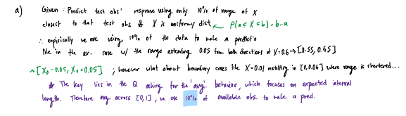

2. Now suppose that we have a set of observations, each with measurements on p = 2 features, X1 and X2. We assume that (X1, X2) are uniformly distributed on [0, 1] × [0, 1]. We wish to predict a test observation’s response using only observations that are within 10 % of the range of X1 and within 10 % of the range of X2 closest to that test observation. For instance, in order to predict the response for a test observation with X1 = 0.6 and X2 = 0.35, we will use observations in the range [0.55, 0.65] for X1 and in the range [0.3, 0.4] for X2. On average, what fraction of the available observations will we use to make the prediction?

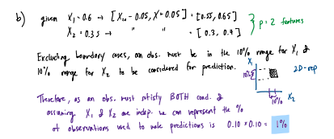

3. Now suppose that we have a set of observations on p = 100 features. Again the observations are uniformly distributed on each feature, and again each feature ranges in value from 0 to 1. We wish to predict a test observation’s response using observations within the 10 % of each feature’s range that is closest to that test observation. What fraction of the available observations will we use to make the prediction?

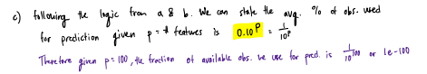

4. Using your answers to parts (a)–(c), argue that a drawback of KNN when p is large is that there are very few training observations “near” any given test observation.

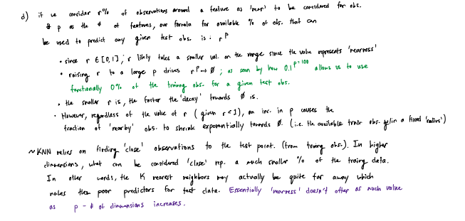

5. Now suppose that we wish to make a prediction for a test observation by creating a p-dimensional hypercube centered around the test observation that contains, on average, 10 % of the training observations. For p = 1, 2, and 100, what is the length of each side of the hypercube? Comment on your answer.

Note: A hypercube is a generalization of a cube to an arbitrary number of dimensions. When p = 1, a hypercube is simply a line segment, when p = 2 it is a square, and when p = 100 it is a 100-dimensional cube.

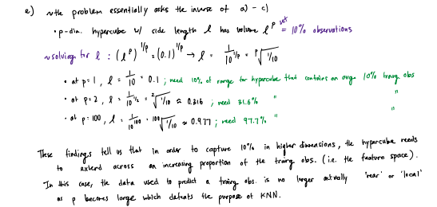